# Replication of Study 1A by Liane Young and Rebecca Saxe (2011, Cognition)

Author

Replication Author[s]: Seyi Lawal

Published

November 22, 2024

## Introduction

The main thesis of the original paper is that while intent matters in making moral judgments, intent will play a smaller role in making moral judgments of purity-related violations vs. harm-related violations. In the first study, the authors test whether for harms and purity violations that are equally wrong, when committed intentionally, there’s a difference in the moral judgment when those actions are committed accidentally. The study is operationalized as a 2 (intent: intentional vs. accidental) x 3 (domain: harm vs. incest vs. ingestion) between subjects design, where participants are presented with moral scenarios and asked to evaluate the extent to which the action is morally wrong on a scale of 1 - 7. There are 2 scenarios representing each domain. The main finding we are planning to replicate are the three, 2 (intent) x 2 (domain) ANOVAs comparing the importance of intent for harm vs. incest, incest vs. ingestion, and harm vs. ingestion. Through the analysis, the authors found an intent by domain interaction when comparing the harm violations to the purity violations, but not the two purity violations to one another.

**Repo Link:** https://github.com/ucsd-psych201a/young2011

**Original Paper Link:** https://github.com/ucsd-psych201a/young2011/tree/main/original_paper

**Paradigm Link:** https://ucsd-psych201a.github.io/young2011/

## Methods

### Power Analysis

The effect size of the main result in the paper (the intent by domain interaction) was 0.15. Given there are 2 groups, 1 degree of freedom, and we’re targeting p < 0.05, We need a sample size of 351 to have 80% power, 469 to have 90% power, and 580 to have 95% power. For this study, we’ll target 80% power.

### Planned Sample

We will screen out repeat participants through the same exclusion rules as the original paper - people who have taken a similar survey before and repeat prolific IDs. We will target 375 participants to have 80% power to detect the main interaction effect in the paper, understanding that some may drop given the exculsion criteria above.

### Materials

Below is the text for the scenarios participants will be prompted with. This follows the original paper exactly.

“Harm

Allergy - Intentional: Imagine your cousin is over for dinner. You know she is allergic to peanuts. You decide to add peanuts to the dish because they really bring out the flavor for you. You grind up the peanuts, add them in, and serve your cousin.

Allergy - Accidental: Imagine your cousin is over for dinner. You have no idea she is allergic to peanuts. You decide to add peanuts to the dish because they really bring out the flavor for you. You grind up the peanuts, add them in, and serve your cousin.

Poison - Intentional: Imagine you and a co-worker are taking a tour of a chemical plant. During the coffee break, you go to pour some coffee. You like yours black, but your co-worker asks for sugar in hers. You spoon some powder into your co-worker’s coffee. You know full well that you are putting poison in her coffee.

Poison - Accidental: Imagine you and a co-worker are taking a tour of a chemical plant. During the coffee break, you go to pour some coffee. You like yours black, but your co-worker asks for sugar in hers. You spoon some powder into your co-worker’s coffee. You do not know that someone replaced the sugar with poison.

Incest

Sibling - Intentional: Imagine you are at a dorm party and really hit it off with someone. This person feels the same way about you. That night, you end up talking, and you discover that you are actually long lost siblings. At the end of the night, you decide to sleep together (using two forms of birth control to be safe).

Sibling - Accidental: Imagine you are at a dorm party and really hit it off with someone. This person feels the same way about you. At the end of the night, you decide to sleep together (using two forms of birth control to be safe). The next day, you end up talking, and you discover that you are actually long lost siblings.

Parent - Intentional: Imagine you were adopted at birth - you have never met your birth parents. The weekend of your college reunion, you go to your school’s football game and meet someone a bit older. You discover that this person is actually your biological parent. You two get along really well and, that night, end up sleeping together (using two forms of birth control to be safe).

Parent - Accidental: Imagine you were adopted at birth - you have never met your birth parents. The weekend of your college reunion, you go to your school’s football game and meet someone a bit older. You have no idea that this person is actually your biological parent. You two get along really well and, that night, end up sleeping together (using two forms of birth control to be safe).

Ingestion

Dog - Intentional: Imagine that a car just killed your beloved dog. Your significant other has heard that dog meat is delicious and freezes the meat of your dog before it goes bad. Later, you decide to make yourself dinner. You see a package in the freezer. It is correctly labeled “dog”. You end up eating your dog for dinner.

Dog - Accidental: Imagine that a car just killed your beloved dog. Your significant other has heard that dog meat is delicious and freezes the meat of your dog before it goes bad. Later, you decide to make yourself dinner. You see a package in the freezer. It is incorrectly labeled “beef” – but it is actually the meat from your dog. Without realizing it, you end up eating your dog for dinner.

Urine - Intentional: Imagine that you are waiting to brush your teeth while your friend is in the bathroom. As she leaves, you notice a cup and a pregnancy test. Your friend warns you that the cup contains her urine for her pregnancy test. You finish brushing your teeth and use that cup to rinse out your mouth.

Urine – Accidental: Imagine that you are waiting to brush your teeth while your friend is in the bathroom. As she leaves, you notice a cup and a pregnancy test. Your friend forgets to tell you that the cup contains her urine for her pregnancy test. You finish brushing your teeth and use that cup to rinse out your mouth. ”

### Procedure

We will follow the procedure exactly as described in the original paper. “Participants were assigned randomly to one of six conditions in a 2 (intentional versus accidental) 3 (harm versus incest versus ingestion) between-subjects experimental design. Participants then judged the moral wrongness of the action [through the question “How morally wrong was the action?”], on a 7-point scale anchored at ‘‘not at all morally wrong’’ (1) to ‘‘very morally wrong’’ (7). Two scenarios represented each domain: harm (allergy, poison), incest (parent, sibling) or ingestion (dog meat, urine). There were two versions of each scenario (intentional, accidental); each participant saw only one version.”

### Analysis Plan

The analysis will follow the original paper exactly. We will first screen out repeat participants through the same exclusion rules as the original paper - people who have taken a similar survey before and repeat prolific IDs. We will then run three, 2 (intent) x 2 (domain) ANOVAs comparing harm vs. incest, harm vs. ingestion, and incest vs. ingestion. The analysis will be collapsed across the 2 scenarios in each domain, as done in the original paper. For the 2 main effects and the interaction, we’ll report the F-stat, p value, and partial eta squared. We will be looking to confirm the intent by domain interaction is significant when comparing the harm violations vs. purity violations, and not significant when comparing the two purity violations.

### Differences from Original Study

The only differences I expect are from the fact that we’re using a different set of participants (different platform - prolific vs. mturk, small differences in final participant count) and the date we’re running the study (late 2000s vs. 2024). In case general perspectives on any of these domains have shifted over time, we could see a change in the results; however, I do not anticipate this to be the case.

### Methods Addendum (Post Data Collection)

#### Differences from pre-data collection methods plan

## Design Overview

- How many factors were manipulated?
  - 2 - intent and domain
- How many measures were taken?
  - 1 - perceptions of moral wrongfulness of the action
- Did it use a within-participants or between-participants design?
  - Between participants
- Were measures repeated?
  - No
- What would have been the consequence of changing one of these decisions? (e.g. moving from within to between participants). Could it have been either way?
  - They could have done a within participants study; however, it would have enlightened the participants to what the manipulation was and possibly have biased participants’ responses.
- Were steps taken to reduce demand characteristics?
  - Only having 1 question per scenario reduces demand characteristics as it’s unclear what the researcher is trying to get at.
- How would you critique the design?
  - Can you think of any potential confounds to the study?
    - It is possible that wtih the accidental purity violations, participants’ do not actually believe the action was an accident (e.g., how can you not realize that you’re eating dog instead of beef, or drinking urine instead of water?). So it would be interesting to test whether with accidental harm violations people actually believe it was an accident more than with accidental purity violations.
  - Do you see any limitations to generalizability?
    - The study chose very specific scenarios of harm vs. purity violations. It’s unclear whether these findings would generate to other purity violations. For example, adultery is considered to be a purity violation in psychology, but I believe people would judge accidental adultery differently from purposeful adultery.

## Results

### Data preparation

Data preparation following the analysis plan.

```r
### Data Preparation

#### Load Relevant Libraries and Functions
install.packages("pacman", repos = "http://cran.us.r-project.org")
pacman::p_load(dplyr,tidyverse,ggplot2,lubridate,stringr,kableExtra, scales)
library(tools)
#### Import data; load data from csv
csv_files <- list.files(path = "~/Coursework/Fall 2024/PSYC 201A/young2011/data/PilotB", pattern = "\\.csv$", full.names = TRUE)

raw_data <- csv_files %>% map_dfr(~ read_csv(.x) %>% mutate(subject = file_path_sans_ext(basename(.x))))
# #### Data exclusion / filtering

## add scenario to response row; then, remove html response rows
cleaned_data <- raw_data %>%
  mutate(
    stimulus = case_when(
      trial_type == "survey-likert" ~ lag(stimulus),
      TRUE ~ stimulus  # Keep the original value if the condition is not met
    )
  )


cleaned_data <- cleaned_data %>% filter(trial_type != "html-keyboard-response")

#remove any participants who say they have take a similar test before
participants_who_have_taken_survey <- cleaned_data %>%
  filter(response == "{\"TakenSurveyBefore\":\"Yes\"}") %>%
  distinct(subject) %>%
  select(subject)

 cleaned_data <- cleaned_data %>%
   anti_join(participants_who_have_taken_survey, by = "subject")


#### Prepare data for analysis - create columns etc.

#create columns for scenario (allergy, poison, sibling incest, parent incest, eating dog, drinking urine), intent (intentional versus accidental), domain (harm versus incest versus ingestion), and violation type (harm vs. purity)
cleaned_data <- cleaned_data %>% mutate(
 scenario = case_when(
   str_detect(stimulus, "You <strong>have no idea</strong> she is allergic to peanuts") ~ "allergy",
   str_detect(stimulus, "<strong>You do not know that someone replaced the sugar with poison.</strong>") ~ "poison",
   str_detect(stimulus, "<strong>The next day, you end up talking, and you discover that you are actually long lost siblings.</strong>") ~ "sibling_incest",
   str_detect(stimulus, "You <strong>have no idea</strong> that this person is actually your biological parent") ~ "parent_incest",
   str_detect(stimulus, "It is <strong>incorrectly labeled “beef”") ~ "eating_dog",
   str_detect(stimulus, "Your friend <strong>forgets to tell you</strong> that the cup contains her urine for her pregnancy test.") ~ "drinking_urine",
   str_detect(stimulus, "You <strong>know</strong> she is allergic to peanuts.") ~ "allergy",
   str_detect(stimulus, "<strong>You know full well that you are putting poison in her coffee.</strong>") ~ "poison",
   str_detect(stimulus, "That night, you end up talking, and you discover that you are actually long lost siblings.") ~ "sibling_incest",
   str_detect(stimulus, "You <strong>discover</strong> that this person is actually your biological parent") ~ "parent_incest",
   str_detect(stimulus, "It is <strong>correctly labeled “dog”</strong>.") ~ "eating_dog",
   str_detect(stimulus, "Your friend <strong>warns</strong> you that the cup contains her urine for her pregnancy test") ~ "drinking_urine"

 )
)

cleaned_data <- cleaned_data %>% mutate(
  domain = case_when(
    scenario == "allergy" ~ "harm",
    scenario == "poison" ~ "harm",
    scenario == "sibling_incest" ~ "incest",
    scenario == "parent_incest" ~ "incest",
    scenario == "eating_dog" ~ "ingestion",
    scenario == "drinking_urine" ~ "ingestion"
  ))

cleaned_data <- cleaned_data %>% mutate(
  violation_type = case_when(
    domain == "harm" ~ "harm",
    domain == "incest" ~ "purity",
    domain == "ingestion" ~ "purity"
  )

)

cleaned_data <- cleaned_data %>% mutate(
  intent = case_when(
    condition == "1" ~ "accidental",
    condition == "2" ~ "intentional"
  )
)

cleaned_data <- cleaned_data %>% filter (trial_type != "survey-multi-choice")

cleaned_data <- cleaned_data %>% mutate(
  moral_wrongness = as.numeric(str_sub(response, 7, 7)) + 1
)

#create subset dataframe for comparing harm vs. incest (filter domain column)

dataframe_harm_incest <- cleaned_data %>% filter(domain == "harm" | domain == "incest")

#create subset dataframe for comparing harm vs. ingestion (filter domain column)

dataframe_harm_ingestion <- cleaned_data %>% filter(domain == "harm" | domain == "ingestion")

#create subset dataframe for comparing incest vs. ingestion (filter domain column)

dataframe_incest_ingestion <- cleaned_data %>% filter(domain == "incest" | domain == "ingestion")
```

### Confirmatory analysis

The analyses as specified in the analysis plan.

```r
#calculate aov comparing harm vs. incest
cat("\n AOV comparing harm vs. incest")
```

```
 AOV comparing harm vs. incest
```

```r
anova_result_harm_incest <- aov(moral_wrongness ~ intent * domain, data = dataframe_harm_incest)
print(summary(anova_result_harm_incest))
```

```
              Df Sum Sq Mean Sq F value  Pr(>F)
intent         1  50.70   50.70  13.634 0.00197 **
domain         1  18.05   18.05   4.854 0.04259 *
intent:domain  1   2.70    2.70   0.726 0.40674
Residuals     16  59.50    3.72
---
Signif. codes:  0 '***' 0.001 '**' 0.01 '*' 0.05 '.' 0.1 ' ' 1
```

```r
#calculate aov comparing harm vs. ingestion
cat("\n AOV comparing harm vs. ingestion")
```

```
 AOV comparing harm vs. ingestion
```

```r
anova_result_harm_igestion <- aov(moral_wrongness ~ intent * domain, data = dataframe_harm_ingestion)
print(summary(anova_result_harm_igestion))
```

```
              Df Sum Sq Mean Sq F value Pr(>F)
intent         1  28.03  28.033   6.158 0.0246 *
domain         1   4.05   4.050   0.890 0.3596
intent:domain  1  12.03  12.033   2.643 0.1235
Residuals     16  72.83   4.552
---
Signif. codes:  0 '***' 0.001 '**' 0.01 '*' 0.05 '.' 0.1 ' ' 1
```

```r
#calculate aov comparing incest vs. ingestion
cat("\n AOV comparing incest vs. ingestion")
```

```
 AOV comparing incest vs. ingestion
```

```r
anova_result_incest_ingestion <- aov(moral_wrongness ~ intent * domain, data = dataframe_incest_ingestion)
print(summary(anova_result_incest_ingestion))
```

```
              Df Sum Sq Mean Sq F value Pr(>F)
intent         1  13.33  13.333   2.530  0.131
domain         1   5.00   5.000   0.949  0.345
intent:domain  1   3.33   3.333   0.632  0.438
Residuals     16  84.33   5.271
```

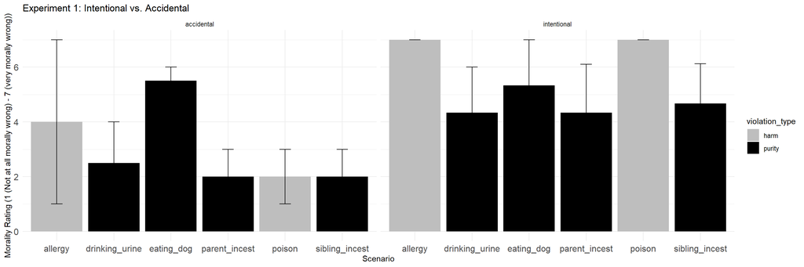

```r
## create bar graph in fig 2
#calculate mean and standard error for moral_wrongness by scenario and intent
df_summary <- cleaned_data %>%
  group_by(scenario, intent) %>%
  summarize(
    mean_moral_wrongness = mean(moral_wrongness),
    se_moral_wrongness = sd(moral_wrongness) / sqrt(n())
  )
#add violation type to summary data frame
df_summary <- df_summary %>% mutate(violation_type =
              case_when(
                scenario == "allergy" ~ "harm",
                scenario == "poison" ~ "harm",
                scenario == "sibling_incest" ~ "purity",
                scenario == "parent_incest" ~ "purity",
                scenario == "eating_dog" ~ "purity",
                scenario == "drinking_urine" ~ "purity"
              ))

#create plot
ggplot(df_summary, aes(x = scenario, y = mean_moral_wrongness,label = scenario, fill = violation_type)) +
  geom_bar(stat = "identity", position = position_dodge(width = 0.8)) +
  geom_errorbar(aes(ymin = mean_moral_wrongness - se_moral_wrongness, ymax = mean_moral_wrongness + se_moral_wrongness),
                width = 0.2, position = position_dodge(width = 0.8)) +
  facet_wrap(~intent, scales = "free_x") + #split intentional vs. accidenta
  scale_fill_manual(values = c("harm" = "gray", "purity" = "black")) + # Color mapping
  labs(x = "Scenario", y = "Morality Rating (1 (Not at all morally wrong) - 7 (very morally wrong))", title = "Experiment 1: Intentional vs. Accidental") +
  theme_minimal() +
    theme(
    axis.text.x = element_text(size = 12),
    axis.text.y = element_text(size = 12)
  )
```